# Homework 2

Jennifer Freeman

24/09/2021

### Jia You’s Graphic

Jia You’s graphic is trying to tell the story that after the introduction of the measles vaccine in 1963, the number of reported measles cases significantly decreased in the two decades following. In other words, the measles vaccine is effective in preventing measles cases.

```r
#measles data set
measles <- (dat
    %>% filter(disease=='Measles')# only keep measles data
    %>% select(cases,year)# only keep relevant columns
)

#vaccine was licensed data set
vaccine <- (measles
    %>% filter(year==1963)
)

#measles data set with vaccine data set removed
measles_less<-(measles
               %>% anti_join(vaccine))
```

### First Plot

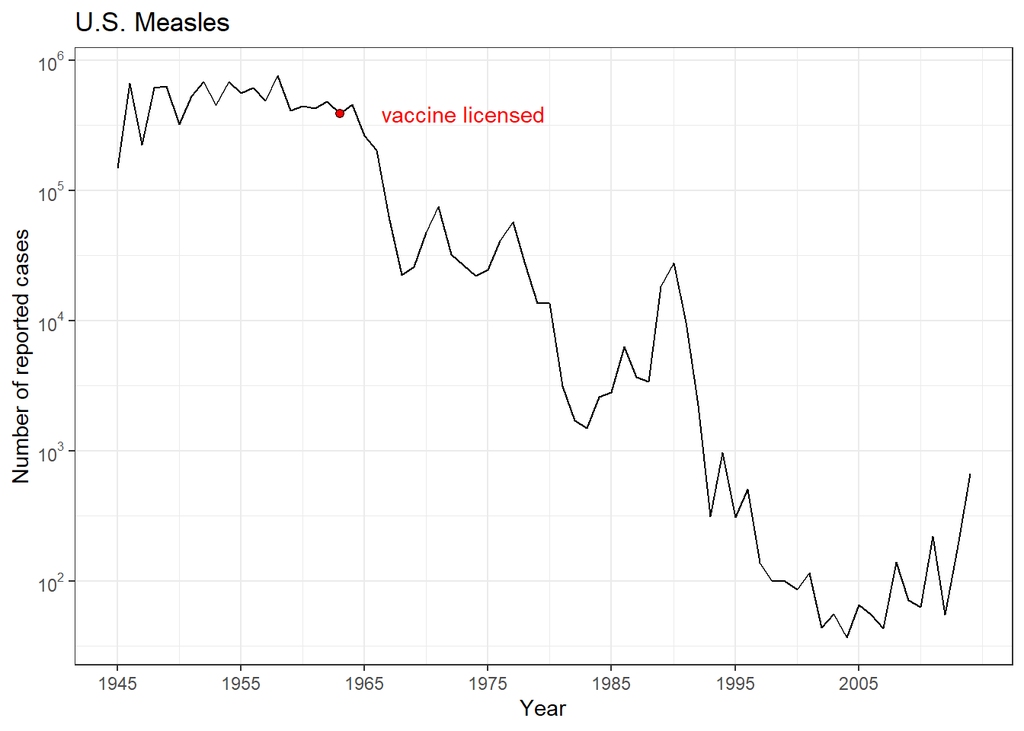

```r
#first plot
(ggplot(measles, aes(x=year, y=cases))
      + geom_line()
      + scale_y_log10(labels = trans_format("log10", math_format(10^.x)))# use log10 scale, convert labels to 10^x format
      + scale_x_continuous(breaks=seq(min(measles[["year"]]),max(measles[["year"]]),10))# use year breaks every 10 years
      + geom_point(data=vaccine, #add point for vaccine license year
                   colour="black",
                   pch=21,
                   fill="red",
                   cex=1.8)
      + geom_text(data=vaccine, #add text for vaccine license year
                  label="vaccine licensed",
                  colour="red",
                  nudge_x=10)
      + labs(x="Year",
             y="Number of reported cases")
      + ggtitle("U.S. Measles")
      + theme_bw()
)
```

My first plot represents the data better because it is uses a better information transfer method on Cleveland’s hierarchy (i.e. position along a common scale, instead of area). In addition, the log scale helps to see the pattern of smaller values more clearly. The overlapping circles in Jia You’s plot are misleading. The area corresponds to the number of recorded cases, and the centre of the circle corresponds to the respective year. However the overlapping circles creates increased colour saturation which leads the viewer to believe the number of recorded cases, especially pre-vaccine, appear higher than they actually are.

### Second Plot (trying to replicate Jia You’s plot)

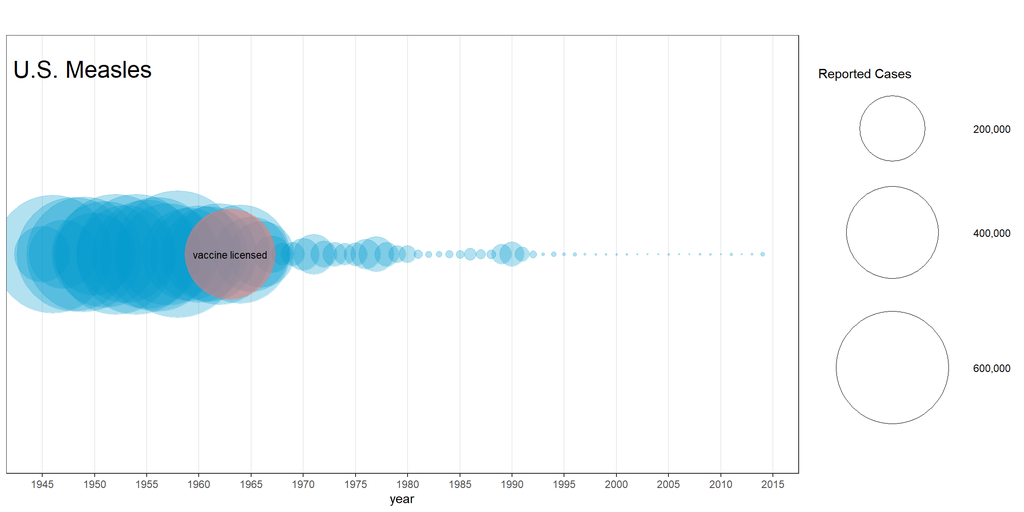

```r
# year breaks for every 5 years
year_breaks = seq(min(measles[["year"]]), max(measles[["year"]])+1, by=5)

#second plot (trying to replicate Jia You's plot)
(ggplot(measles_less, aes(x=year, y=1, size=cases))#arbitrary y value
      + geom_point(alpha=0.3,
                   colour="deepskyblue3")
      + geom_point(data=vaccine, #add point for vaccine license year
                   aes(x=year,
                       y=1,
                       size=cases,
                       alpha=0.3,
                       color="orange")
                   )
      + geom_text(data=vaccine, #add text for vaccine license year
                  size=3,
                  label="vaccine licensed",
                  colour="black")
      + theme_bw()
      + theme(plot.title = element_text(vjust=-10, hjust=10^-2, size=20)) #move plot title to inside the graph window
      + ggtitle("U.S. Measles")
      + scale_size_area(max_size=50, labels= scales::comma) #use commas in legend
      + scale_y_continuous(labels=NULL, breaks=NULL) #get rid of y axis as it doesn't represent anything
      + ylab(label=NULL)
      + scale_x_continuous(breaks=year_breaks, minor_breaks=NULL) #use year breaks defined above
      + guides(colour="none", #get rid of colour and alpha legends
               alpha="none",
               size=guide_legend(override.aes = list(pch=1), title="Reported Cases") #make legend points 'open' circles instead of filled
               )
)
```

I wasted a good amount of time trying to find interesting data to include, and landed on trying to replicate Jia You’s plot. I struggled to replicate the legend. Is there a way to make the circles in the legend nested as in the graphic? I could also not figure out how to specify the sizes in the legend that would correspond to specific ‘number of cases’ values. For example, if I wanted to include the circle that corresponds to 1000 cases, how would I work back to determine how ggplot2 assigns the size for this number of cases?